# R Notebook

Reference: https://github.com/zkneupper/Default-Prediction-Capstone/blob/master/notebooks/Data-Wrangling.ipynb Emails with professor who provided the datasets: https://www.kaggle.com/uciml/default-of-credit-card-clients-dataset/discussion/34608

```r
library(plyr)
library(dplyr)
library(Hmisc)
library(ggpubr)
library(DMwR)
library(caret)
library(pROC)
library(ggplot2)
library(ggpubr)
```

## II. Business Understanding

## III. Data Understanding

This research employed a binary variable, default payment (Yes = 1, No = 0), as the response variable. This study reviewed the literature and used the following 23 variables as explanatory variables: X1: Amount of the given credit (NT dollar): it includes both the individual consumer credit and his/her family (supplementary) credit. X2: Gender (1 = male; 2 = female). X3: Education (1 = graduate school; 2 = university; 3 = high school; 4 = others). X4: Marital status (1 = married; 2 = single; 3 = others). X5: Age (year). X6 - X11: History of past payment. We tracked the past monthly payment records (from April to September, 2005) as follows: X6 = the repayment status in September, 2005; X7 = the repayment status in August, 2005; . . .;X11 = the repayment status in April, 2005. The measurement scale for the repayment status is: -1 = pay duly; 1 = payment delay for one month; 2 = payment delay for two months; . . .; 8 = payment delay for eight months; 9 = payment delay for nine months and above. X12-X17: Amount of bill statement (NT dollar). X12 = amount of bill statement in September, 2005; X13 = amount of bill statement in August, 2005; . . .; X17 = amount of bill statement in April, 2005. X18-X23: Amount of previous payment (NT dollar). X18 = amount paid in September, 2005; X19 = amount paid in August, 2005; . . .;X23 = amount paid in April, 2005.

## IV. Data Exploration and Preparation

```r
model_dir = "models"
data_dir = "data"
```

Factorize the variables and give values meanningful names:

```r
### Loading data
data=read.csv(paste(data_dir,"default.csv",sep="/"), header = TRUE, sep = ",",na.strings = "NA")
# apply(data,2,function(x){sum(is.na(x))/length(x)*100})
# 1 = male; 2 = female
data$SEX = factor(mapvalues(data$SEX, from = c(1, 2), to = c("MALE", "FEMALE")))
# 1 = graduate school; 2 = university; 3 = high school; 4 = others
data$EDUCATION = factor(mapvalues(data$EDUCATION, from = c(0,1,2,3,4,5,6), to = c("others","graduate school", "university", "high school", "others", "others", "others")))
# 1 = married; 2 = single; 3 = others
data$MARRIAGE = factor(mapvalues(data$MARRIAGE, from = c(0,1,2,3), to = c("others", "married", "single","divorced")))
data$default.payment.next.month = factor(mapvalues(data$default.payment.next.month,from = c(0,1), to = c("no","yes")))
y = data$default.payment.next.month
data = data[,-dim(data)[2]]
data$y = y
```

Show basic statistics for all columns:

```r
str(data)
```

```
'data.frame':   30000 obs. of  25 variables:
 $ ID       : int  1 2 3 4 5 6 7 8 9 10 ...
 $ LIMIT_BAL: int  20000 120000 90000 50000 50000 50000 500000 100000 140000 20000 ...
 $ SEX      : Factor w/ 2 levels "FEMALE","MALE": 1 1 1 1 2 2 2 1 1 2 ...
 $ EDUCATION: Factor w/ 4 levels "graduate school",..: 4 4 4 4 4 1 1 4 2 2 ...
 $ MARRIAGE : Factor w/ 4 levels "divorced","married",..: 2 4 4 2 2 4 4 4 2 4 ...
 $ AGE      : int  24 26 34 37 57 37 29 23 28 35 ...
 $ PAY_0    : int  2 -1 0 0 -1 0 0 0 0 -2 ...
 $ PAY_2    : int  2 2 0 0 0 0 0 -1 0 -2 ...
 $ PAY_3    : int  -1 0 0 0 -1 0 0 -1 2 -2 ...
 $ PAY_4    : int  -1 0 0 0 0 0 0 0 0 -2 ...
 $ PAY_5    : int  -2 0 0 0 0 0 0 0 0 -1 ...
 $ PAY_6    : int  -2 2 0 0 0 0 0 -1 0 -1 ...
 $ BILL_AMT1: int  3913 2682 29239 46990 8617 64400 367965 11876 11285 0 ...
 $ BILL_AMT2: int  3102 1725 14027 48233 5670 57069 412023 380 14096 0 ...
 $ BILL_AMT3: int  689 2682 13559 49291 35835 57608 445007 601 12108 0 ...
 $ BILL_AMT4: int  0 3272 14331 28314 20940 19394 542653 221 12211 0 ...
 $ BILL_AMT5: int  0 3455 14948 28959 19146 19619 483003 -159 11793 13007 ...
 $ BILL_AMT6: int  0 3261 15549 29547 19131 20024 473944 567 3719 13912 ...
 $ PAY_AMT1 : int  0 0 1518 2000 2000 2500 55000 380 3329 0 ...
 $ PAY_AMT2 : int  689 1000 1500 2019 36681 1815 40000 601 0 0 ...
 $ PAY_AMT3 : int  0 1000 1000 1200 10000 657 38000 0 432 0 ...
 $ PAY_AMT4 : int  0 1000 1000 1100 9000 1000 20239 581 1000 13007 ...
 $ PAY_AMT5 : int  0 0 1000 1069 689 1000 13750 1687 1000 1122 ...
 $ PAY_AMT6 : int  0 2000 5000 1000 679 800 13770 1542 1000 0 ...
 $ y        : Factor w/ 2 levels "no","yes": 2 2 1 1 1 1 1 1 1 1 ...
```

```r
summary(data)
```

```
       ID          LIMIT_BAL           SEX                  EDUCATION         MARRIAGE          AGE            PAY_0             PAY_2             PAY_3             PAY_4             PAY_5             PAY_6           BILL_AMT1         BILL_AMT2
 Min.   :    1   Min.   :  10000   FEMALE:18112   graduate school:10585   divorced:  323   Min.   :21.00   Min.   :-2.0000   Min.   :-2.0000   Min.   :-2.0000   Min.   :-2.0000   Min.   :-2.0000   Min.   :-2.0000   Min.   :-165580   Min.   :-69777
 1st Qu.: 7501   1st Qu.:  50000   MALE  :11888   high school    : 4917   married :13659   1st Qu.:28.00   1st Qu.:-1.0000   1st Qu.:-1.0000   1st Qu.:-1.0000   1st Qu.:-1.0000   1st Qu.:-1.0000   1st Qu.:-1.0000   1st Qu.:   3559   1st Qu.:  2985
 Median :15000   Median : 140000                  others         :  468   others  :   54   Median :34.00   Median : 0.0000   Median : 0.0000   Median : 0.0000   Median : 0.0000   Median : 0.0000   Median : 0.0000   Median :  22382   Median : 21200
 Mean   :15000   Mean   : 167484                  university     :14030   single  :15964   Mean   :35.49   Mean   :-0.0167   Mean   :-0.1338   Mean   :-0.1662   Mean   :-0.2207   Mean   :-0.2662   Mean   :-0.2911   Mean   :  51223   Mean   : 49179
 3rd Qu.:22500   3rd Qu.: 240000                                                           3rd Qu.:41.00   3rd Qu.: 0.0000   3rd Qu.: 0.0000   3rd Qu.: 0.0000   3rd Qu.: 0.0000   3rd Qu.: 0.0000   3rd Qu.: 0.0000   3rd Qu.:  67091   3rd Qu.: 64006
 Max.   :30000   Max.   :1000000                                                           Max.   :79.00   Max.   : 8.0000   Max.   : 8.0000   Max.   : 8.0000   Max.   : 8.0000   Max.   : 8.0000   Max.   : 8.0000   Max.   : 964511   Max.   :983931
   BILL_AMT3         BILL_AMT4         BILL_AMT5        BILL_AMT6          PAY_AMT1         PAY_AMT2          PAY_AMT3         PAY_AMT4         PAY_AMT5           PAY_AMT6          y
 Min.   :-157264   Min.   :-170000   Min.   :-81334   Min.   :-339603   Min.   :     0   Min.   :      0   Min.   :     0   Min.   :     0   Min.   :     0.0   Min.   :     0.0   no :23364
 1st Qu.:   2666   1st Qu.:   2327   1st Qu.:  1763   1st Qu.:   1256   1st Qu.:  1000   1st Qu.:    833   1st Qu.:   390   1st Qu.:   296   1st Qu.:   252.5   1st Qu.:   117.8   yes: 6636
 Median :  20088   Median :  19052   Median : 18104   Median :  17071   Median :  2100   Median :   2009   Median :  1800   Median :  1500   Median :  1500.0   Median :  1500.0
 Mean   :  47013   Mean   :  43263   Mean   : 40311   Mean   :  38872   Mean   :  5664   Mean   :   5921   Mean   :  5226   Mean   :  4826   Mean   :  4799.4   Mean   :  5215.5
 3rd Qu.:  60165   3rd Qu.:  54506   3rd Qu.: 50190   3rd Qu.:  49198   3rd Qu.:  5006   3rd Qu.:   5000   3rd Qu.:  4505   3rd Qu.:  4013   3rd Qu.:  4031.5   3rd Qu.:  4000.0
 Max.   :1664089   Max.   : 891586   Max.   :927171   Max.   : 961664   Max.   :873552   Max.   :1684259   Max.   :896040   Max.   :621000   Max.   :426529.0   Max.   :528666.0
```

### (1) Visualizations

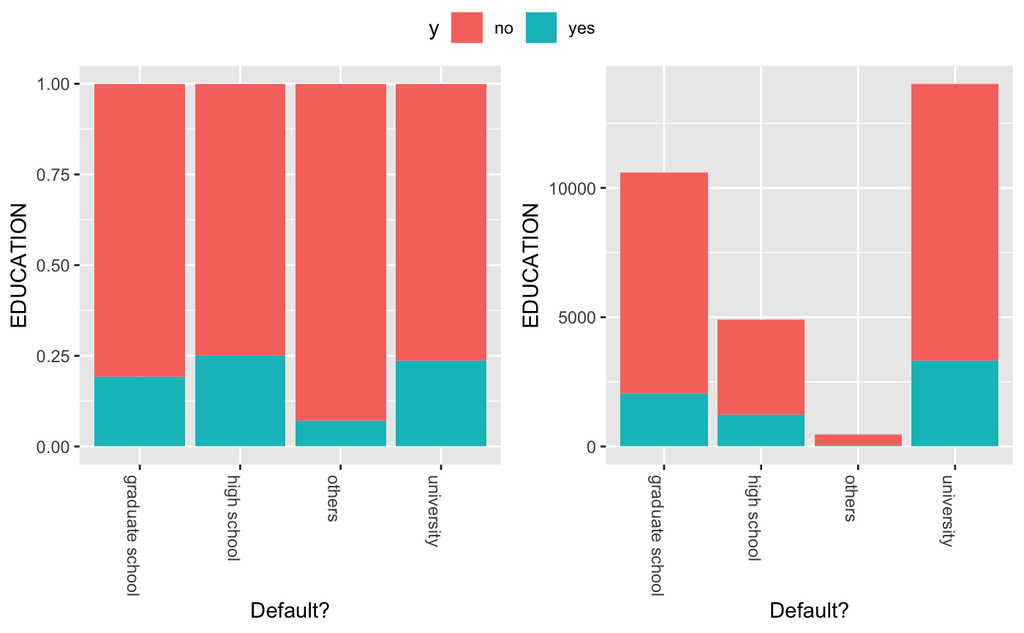

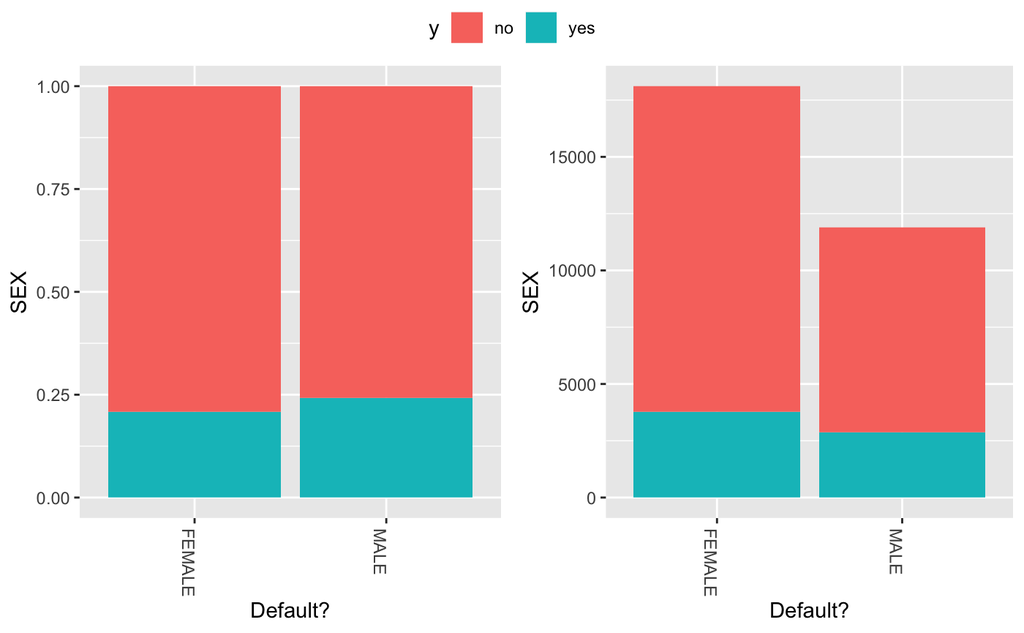

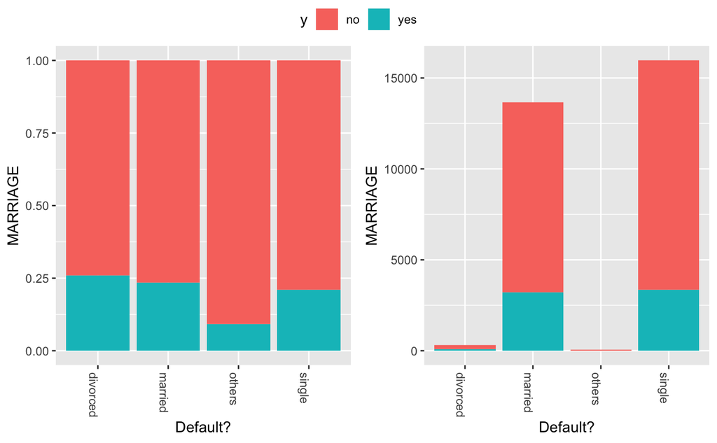

```r
for (col in names(data[,-c(1,dim(data)[2])])) {
    if(!is.factor(data[,col])) next
    p1 = ggplot(data, aes(data[,col], fill = y)) + geom_bar(position="fill") +
      labs(x = "Default?", y = col) +
      theme(axis.text.x=element_text(angle = -90, hjust = 0))
    p2 = ggplot(data, aes(data[,col], fill = y)) + geom_bar() +
      labs(x = "Default?", y = col) +
      theme(axis.text.x=element_text(angle = -90, hjust = 0))
    p3 = ggarrange(p1, p2, ncol = 2, nrow = 1, common.legend = TRUE)
    print(p3)
}
```

### (3) Data outliers

Box plots were created to see if there were any outliers that should be addressed.

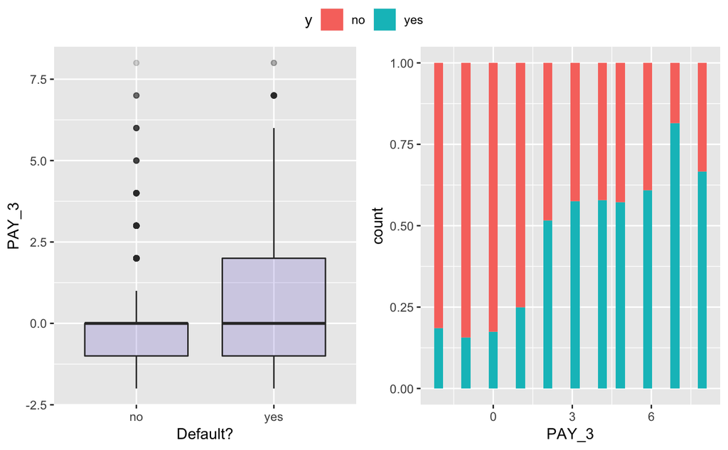

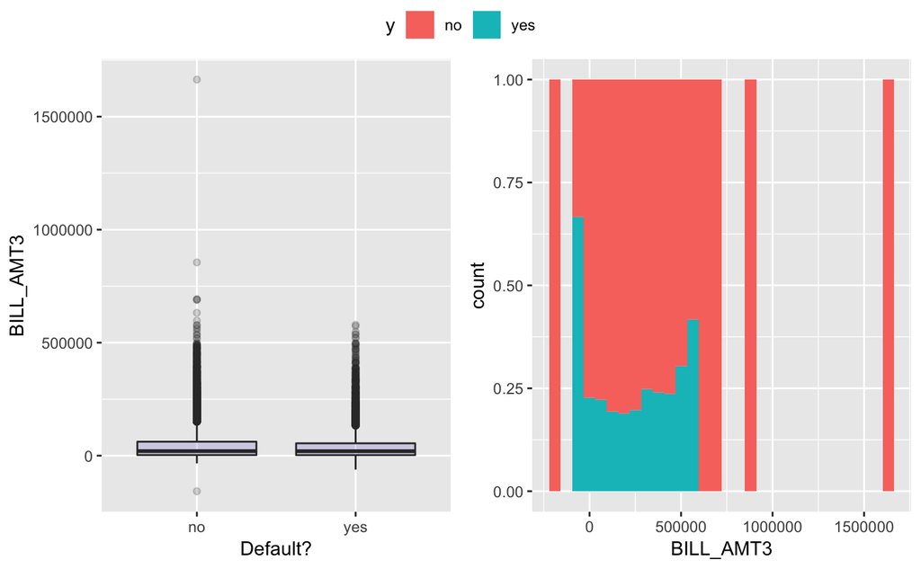

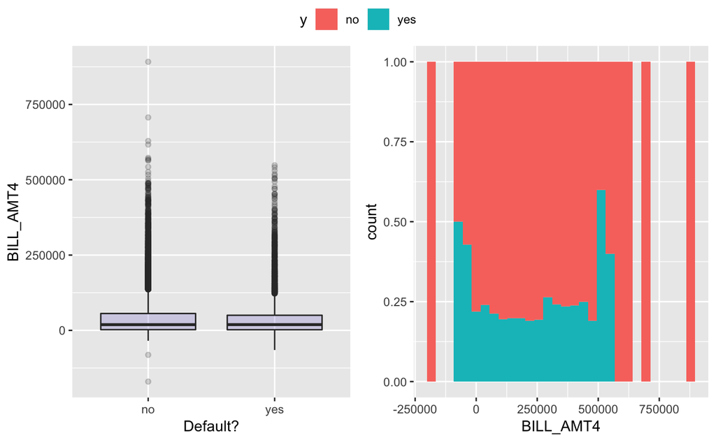

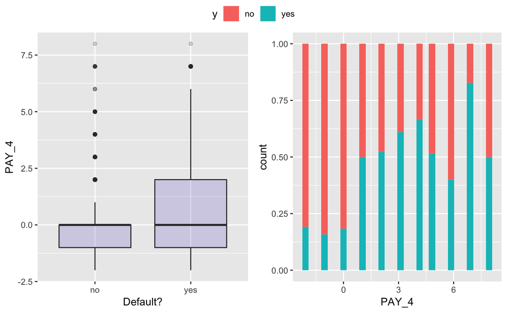

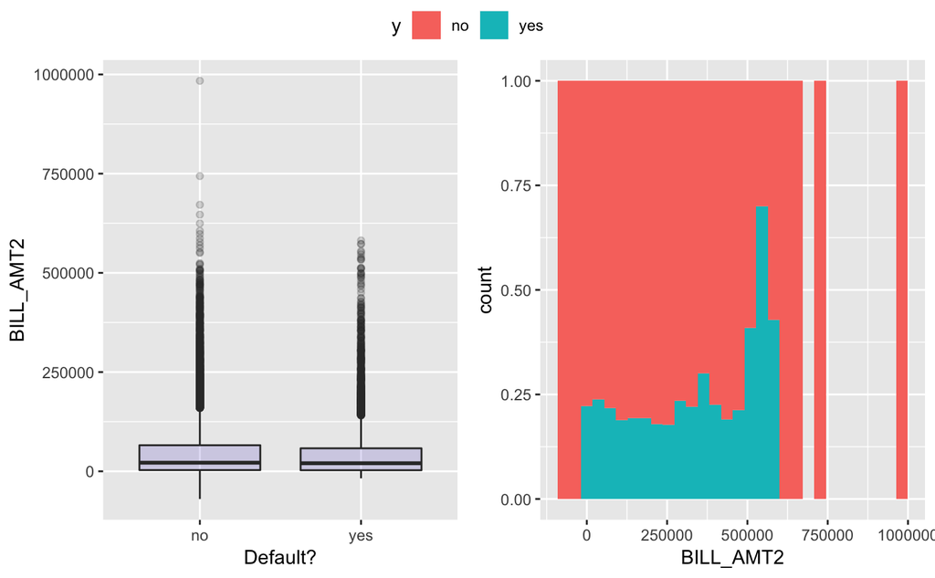

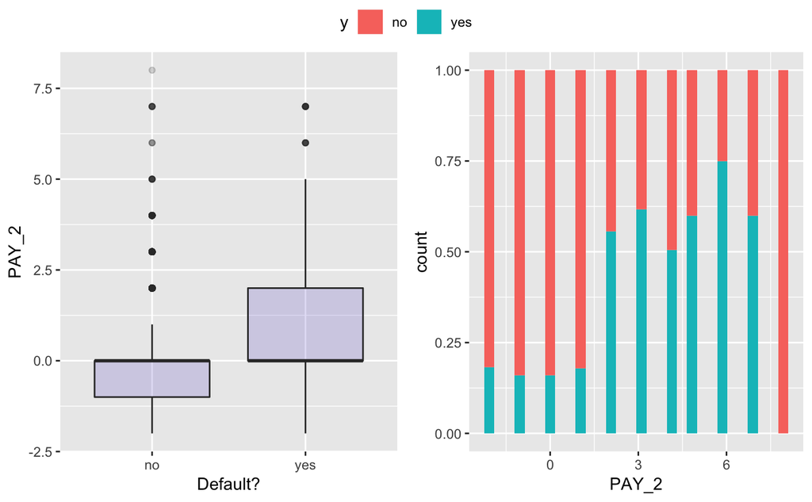

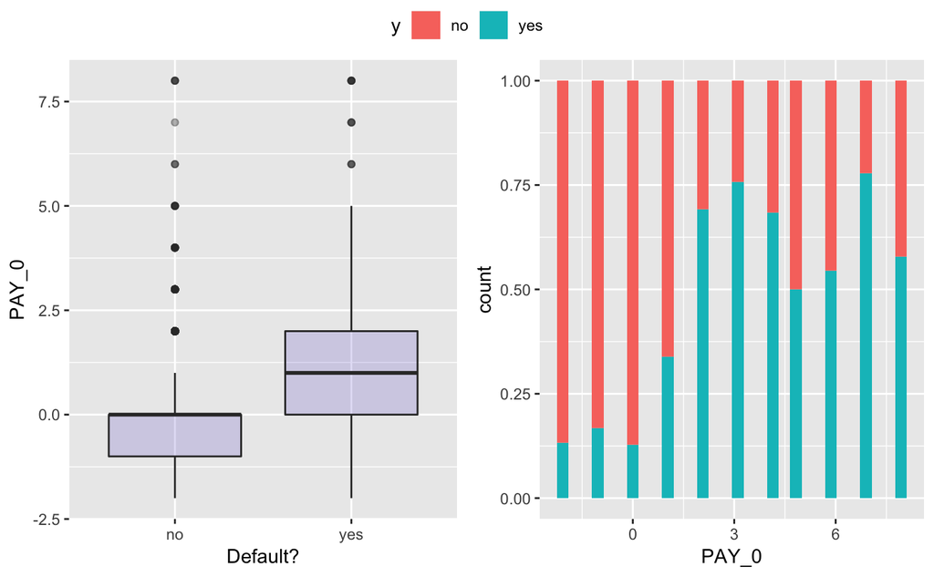

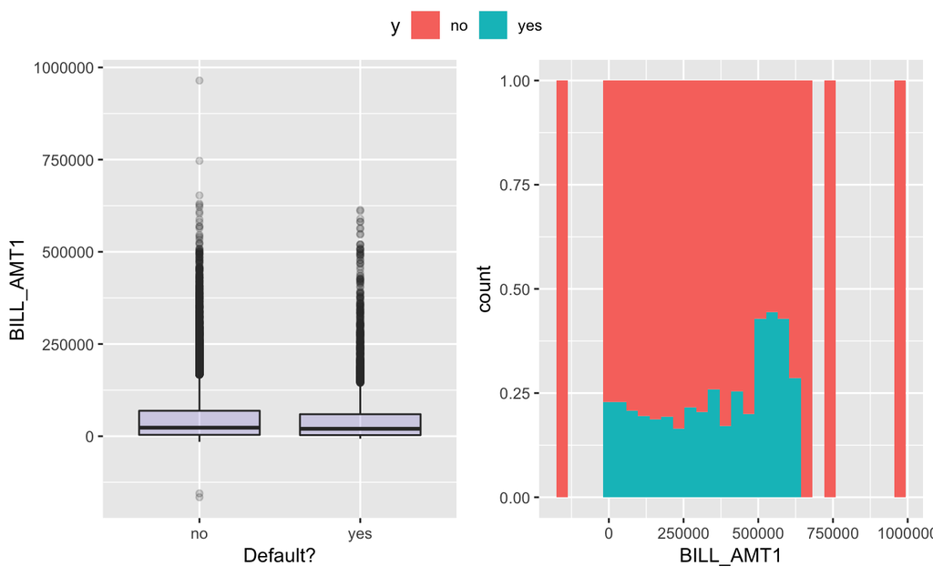

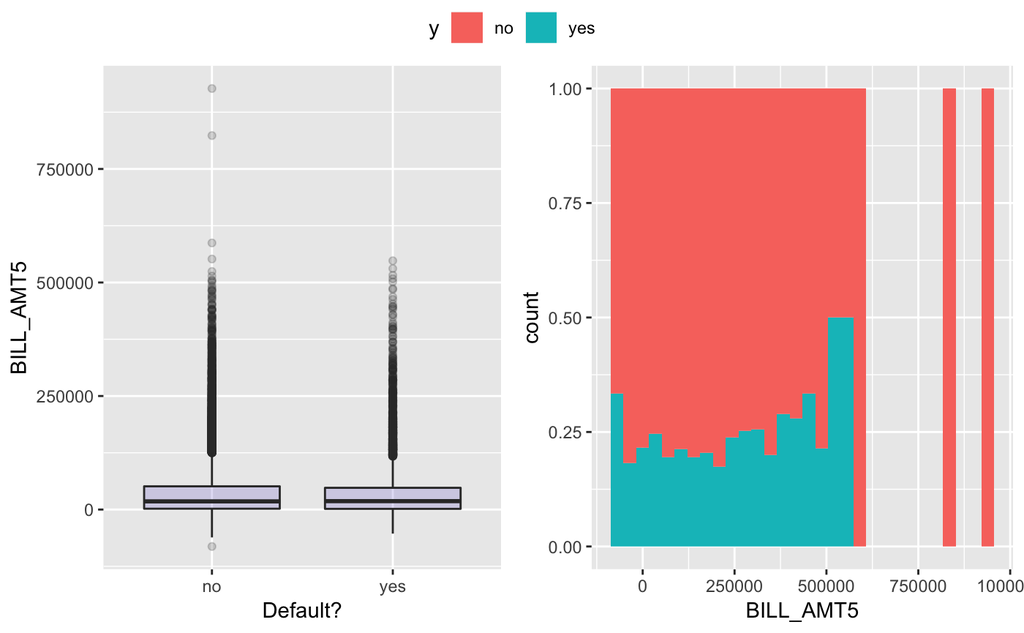

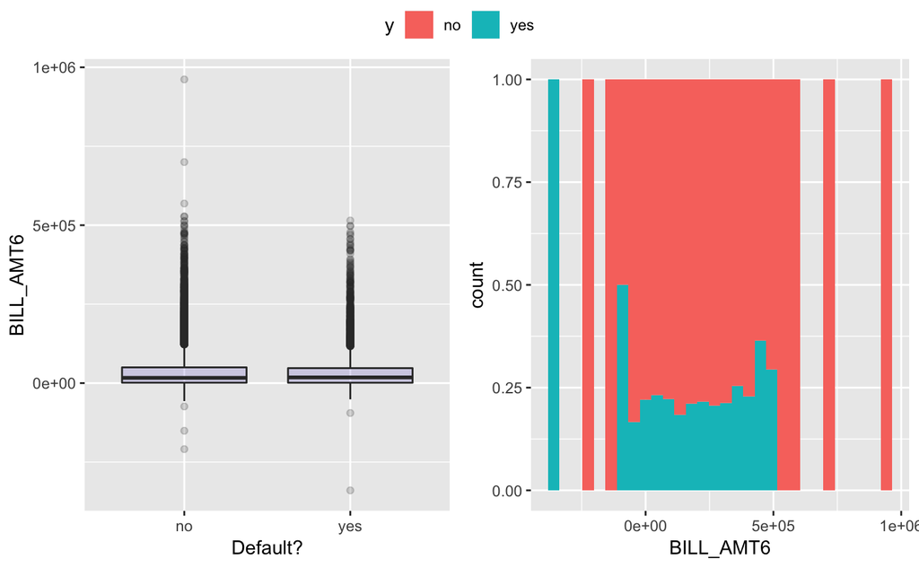

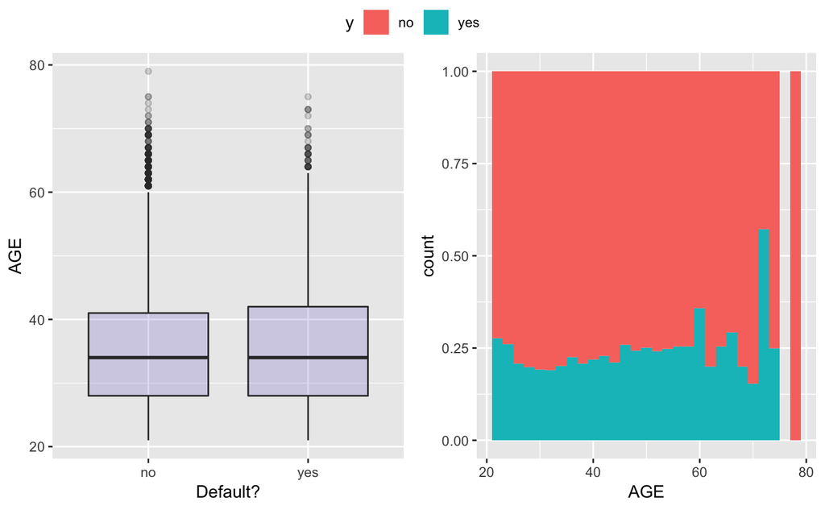

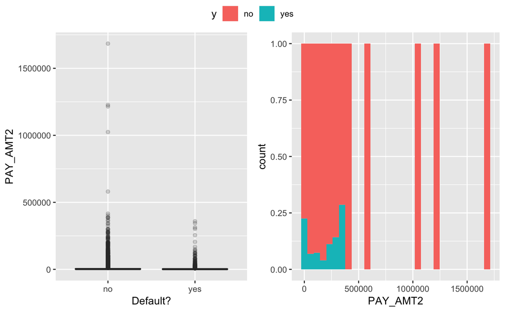

[8 more figures not shown]

```r
# box plot for all numeric input ~ y
draw_box_plot = function() {
  for (i in 2:(length(data)-1)) {
    col = colnames(data)[i];
    if(!is.numeric(data[,i])) next
    p1 = ggplot(data, aes(x=y, y=data[,i])) +
      geom_boxplot(fill="slateblue", alpha=0.2) +
      xlab("Default?") + ylab(col)
    p2 = ggplot(data, aes(x=data[,col],fill=y)) + geom_histogram(position = "fill") + xlab(col)
    p3 = ggarrange(p1, p2, ncol = 2, nrow = 1, common.legend = TRUE)
    print(p3)
  }
}
draw_box_plot()
```

### (4) Data Preprocessing

```r
set.seed(42)
split = createDataPartition(data$y, times = 1, p=0.25, list = F)
train = data[split,]
test = data[-split,]
train_x = train[,names(train)!="y"]
train_y = train$y
folds <- createFolds(train_y, k = 5)
myControl <- trainControl(
  summaryFunction = twoClassSummary,
  classProbs = TRUE,
  savePredictions = TRUE,
  index = folds,
  verboseIter = F
)
```

## V. Modeling

### (2) Classification Tree

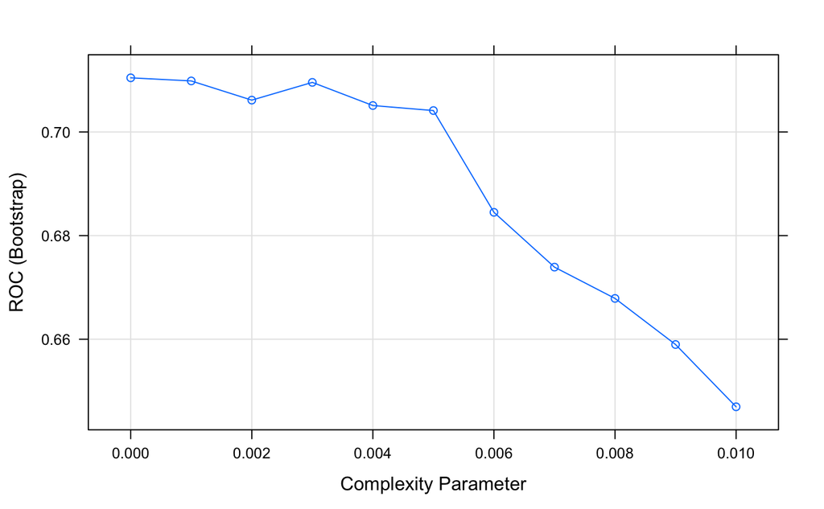

```r
if(!exists("model_rpart")) {
  model_rpart <- train(
  y ~ ., train,
  metric = "ROC",
  method = "rpart",
  trControl = myControl,
  tuneGrid = expand.grid(
    cp = seq(0,0.01,0.001)
  )
)
}
plot(model_rpart)
```

### (3) Naive Bayes

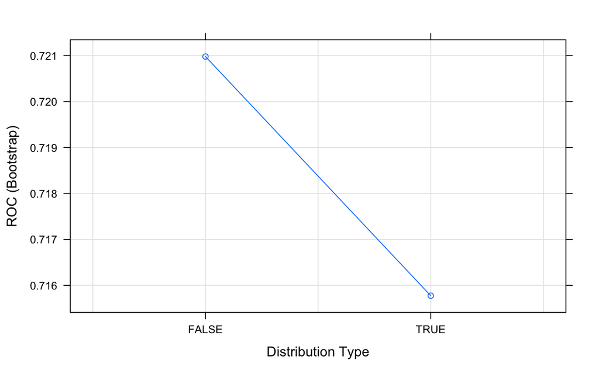

```r
if(!exists("model_nb")) {
  model_nb <- train(
  y ~ ., train,
  metric = "ROC",
  method = "naive_bayes",
  trControl = myControl
)
}
plot(model_nb)
```

### (4) Generalized Linear Model (glmnet):

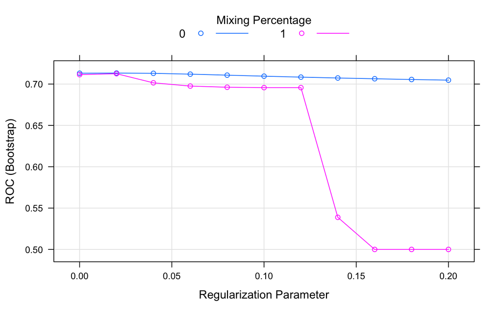

```r
if(!exists("model_glmnet")) {
  model_glmnet <- caret::train(
  y ~ ., train,
  metric = "ROC",
  method = "glmnet",
  tuneGrid = expand.grid(
    alpha = c(0,1),
    lambda = 10:0/50
  ),
  trControl = myControl
)
}
plot(model_glmnet)
```

### (5) glmnet with PCA preprocessing

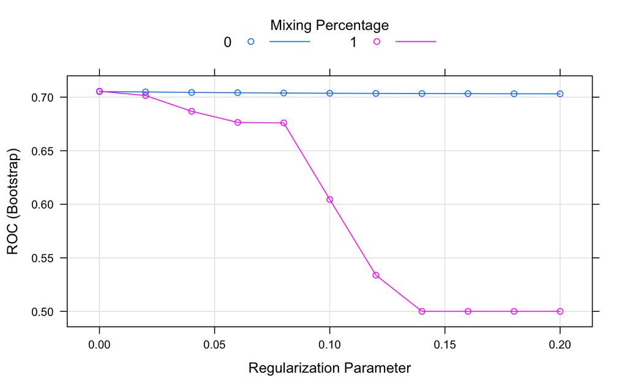

```r
if(!exists("model_glmnet_pca")) {
  model_glmnet_pca <- train(
    y ~ ., train,
    metric = "ROC",
    method = "glmnet",
    tuneGrid = expand.grid(
      alpha = c(0,1),
      lambda = 10:0/50
    ),
    trControl = myControl,
    preProcess = c("zv", "nzv","center","scale","pca")
  )
}
plot(model_glmnet_pca)
```

### (7) Random Forest

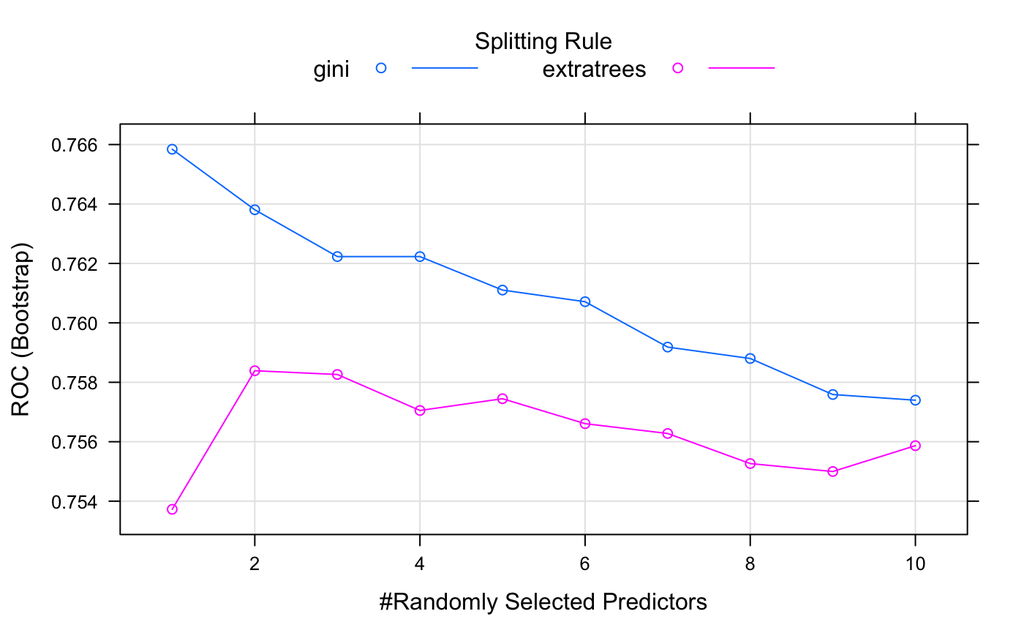

```r
if(!exists("model_rf")) {
  model_rf <- caret::train(
  y ~ ., train,
  metric = "ROC",
  method = "ranger",
  importance = 'impurity',
  trControl = myControl,
  tuneGrid = expand.grid(
    mtry = seq(1,10,1),
    splitrule = c("gini","extratrees"),
    min.node.size = c(1)
  )
)
}
plot(model_rf)
```

## VI. Evaluation

```r
model_list = list(rf=model_rf,
                  glmnet=model_glmnet,
                  glmnet_pca=model_glmnet_pca,
                  rpart=model_rpart,
                  nb=model_nb
                  )
resamps <- resamples(model_list)
summary(resamps, metric = "ROC")
```

```
Call:
summary.resamples(object = resamps, metric = "ROC")

Models: rf, glmnet, glmnet_pca, rpart, nb
Number of resamples: 5

ROC
                Min.   1st Qu.    Median      Mean   3rd Qu.      Max. NA's
rf         0.7556207 0.7650503 0.7654703 0.7658423 0.7680714 0.7749990    0
glmnet     0.7065769 0.7118659 0.7135285 0.7132717 0.7152405 0.7191467    0
glmnet_pca 0.7002029 0.7054896 0.7055542 0.7055536 0.7066639 0.7098574    0
rpart      0.6987695 0.7016867 0.7120855 0.7104581 0.7172321 0.7225164    0
nb         0.7114312 0.7137594 0.7215233 0.7209804 0.7215862 0.7366016    0
```

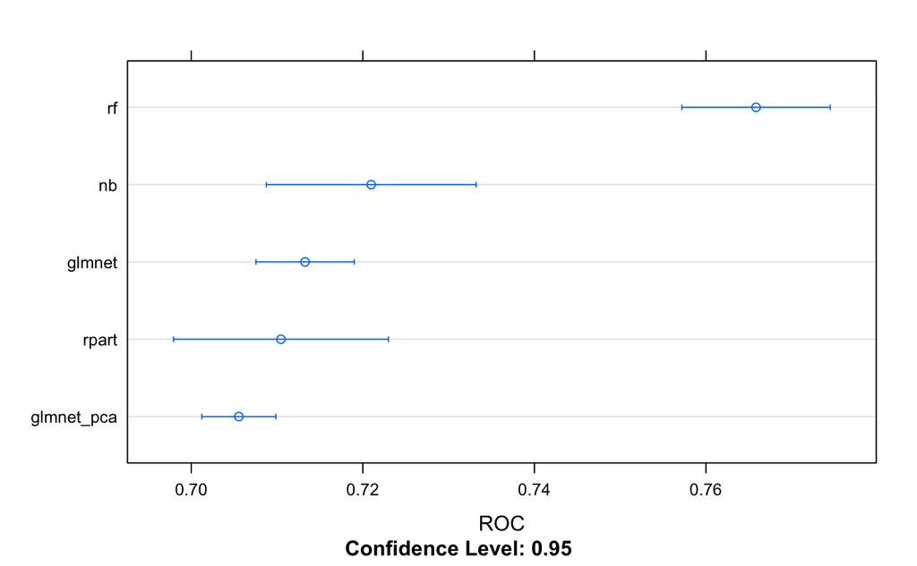

```r
dotplot(resamps, metric = "ROC")
```